# Aiming a Spinner

4 Dec 2019

## Introduction

## Spinners are used to randomize

Wheel of Fortune:

[figure not shown]

MarioGS, CC 3.0

## Spinners are useful metaphors

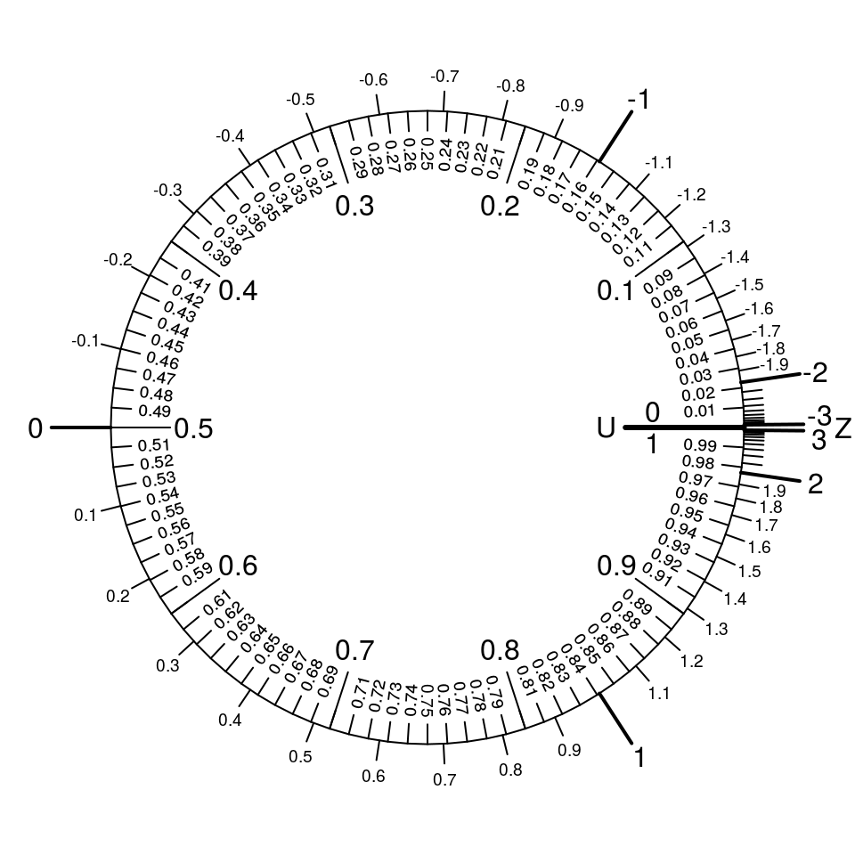

\[P(0<Z<1)~\approx~0.84-0.5 \]

## But how random are spinners?

- Spinners are not inherently chaotic
- I guessed I would be able to repeatedly spin a spinner \(2.5\pm0.5\) rotations without much trouble.

## Method

## Spinner

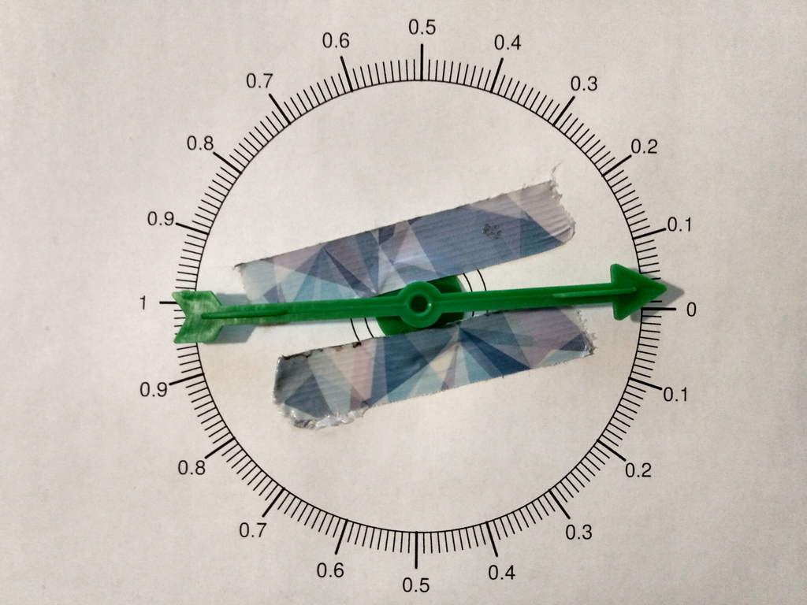

## Spinner

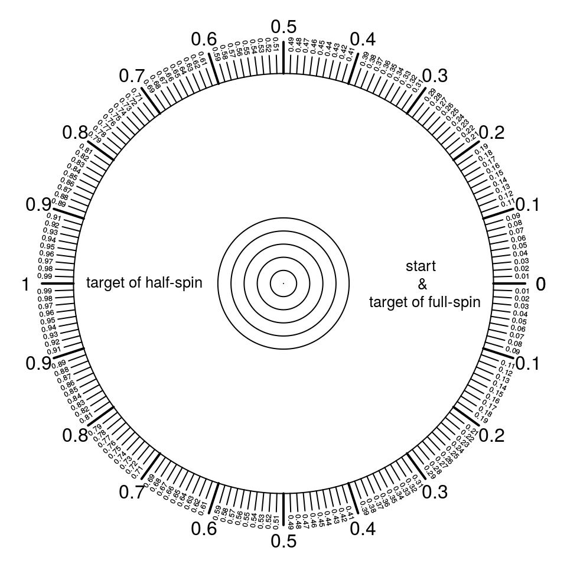

## Two types of trials

- 100 trials attempted to spin 1/2 a rotation to land on the 1
- 100 trials attempted to spin 1 full rotation to land on the 0
- If accurate, I would get a sample mean significantly above (or below) 0.5
- If spins are random, the sample mean should be approximately 0.5 (\(\pm\) SE)
- The standard uniform distribution has \(\mu = 0.5\) and \(\sigma = \sqrt{\frac{1}{12}}\)
- see uniform distribution

## Hypothesis testing

\[H_0 ~~~\text{ claims }~~~ \mu=0.5 \text{ and } \sigma =\sqrt{\frac{1}{12}}\] When 100 random spins are spun, the sampling distribution of the sample mean should be normally distributed. \[\text{With }n=100,~H_0 ~~\text{claims}~~ \bar{x}\sim \mathcal{N}\left(0.5,\,\frac{\sqrt{\frac{1}{12}}}{\sqrt{100}}\right) \] If \(H_0\) is true, we expect the sample mean to be between 0.443 and 0.557. (Determined with \(z=1.96\) and \(\mu \pm \frac{z\sigma}{\sqrt{n}}\)) \[P(0.443 < \bar{x} < 0.557) ~=~ 0.95 \]

## Results

## Histograms

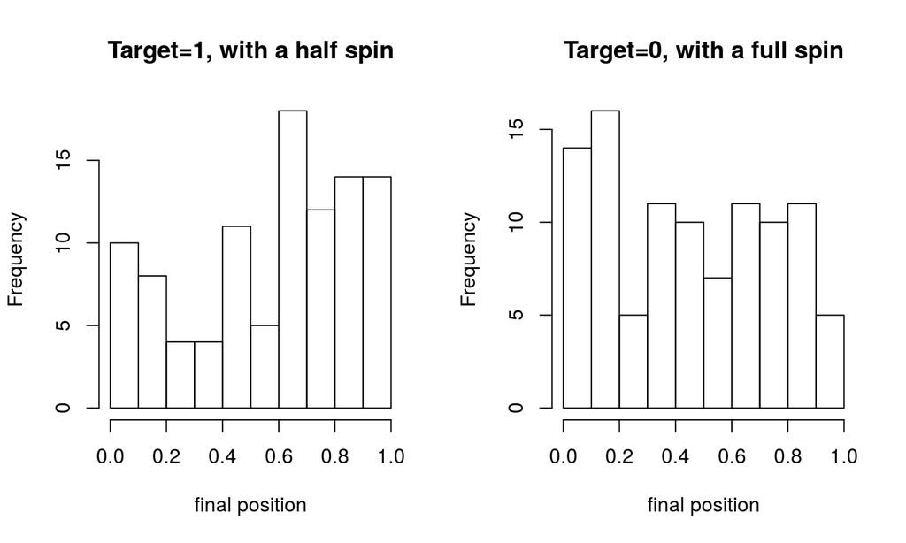

## Hypothesis test results

| Statistic | Half spin | Full spin |
| --- | --- | --- |
| \(n\) | 100 | 100 |
| \(\bar{x}\) | 0.585 | 0.456 |
| \(z\) | 2.93 | -1.53 |
| \(p\)-value (two-tail) | 0.0034 | 0.13 |

- In 100 spins, I was significantly better than random at aiming a half-spin at the 1.
- In 100 spins, I was not significantly better than random at aiming a full-spin at the 0.

## 95% Confidence intervals

\(df = 99\) and \(t^\star = 1.98\)

| Statistic | Half spin | Full spin |
| --- | --- | --- |
| \(n\) | 100 | 100 |
| \(\bar{x}\) | 0.585 | 0.456 |
| \(s\) | 0.293 | 0.293 |
| \(t^\star\frac{s}{\sqrt{n}}\) | 0.058 | 0.058 |
| \(LB= \bar{x}-t^\star\frac{s}{\sqrt{n}}\) | 0.53 | 0.4 |
| \(UB= \bar{x}+t^\star\frac{s}{\sqrt{n}}\) | 0.64 | 0.51 |

## 95% Confidence intervals

When attempting to make a half-spin, I am 95% confident that the expected value is between 0.53 and 0.64 \[CI_{\text{half-spin}} ~=~ (0.53,~0.64) \] When attempting to make a full-spin, I am 95% confident that the expected value is between 0.4 and 0.51 \[CI_{\text{full-spin}} ~=~ (0.4,~0.51) \]

## Discussion

## Discussion

- I was able to significantly beat random spins when targeting a half-spin
- Aiming the spinner proved more difficult than I guessed before
- I wonder how successful other people would be
- I wonder how difficult it is to alter the probabilities of other randomization devices